# Introduction

This project aims to perform a detailed data anlysis on the Titanic data set and draw conclusions on which passengers were more likely to survive the disaster and what factors contibuted to survival. The data has been obtained from https://www.kaggle.com/c/titanic

Here is a sample of the data, it is described in detail below.

```python
import numpy as np
import pandas as pd


# Read from csv into a pandas dataframe
titanic_data_raw = pd.read_csv('titanic-data.csv')

# Display first 10 rows of the data
titanic_data_raw.head(10)
```

|  | PassengerId | Survived | Pclass | Name | Sex | Age | SibSp | Parch | Ticket | Fare | Cabin | Embarked |
| --- | --- | --- | --- | --- | --- | --- | --- | --- | --- | --- | --- | --- |
| 0 | 1 | 0 | 3 | Braund, Mr. Owen Harris | male | 22.0 | 1 | 0 | A/5 21171 | 7.2500 | NaN | S |
| 1 | 2 | 1 | 1 | Cumings, Mrs. John Bradley (Florence Briggs Th... | female | 38.0 | 1 | 0 | PC 17599 | 71.2833 | C85 | C |
| 2 | 3 | 1 | 3 | Heikkinen, Miss. Laina | female | 26.0 | 0 | 0 | STON/O2. 3101282 | 7.9250 | NaN | S |
| 3 | 4 | 1 | 1 | Futrelle, Mrs. Jacques Heath (Lily May Peel) | female | 35.0 | 1 | 0 | 113803 | 53.1000 | C123 | S |
| 4 | 5 | 0 | 3 | Allen, Mr. William Henry | male | 35.0 | 0 | 0 | 373450 | 8.0500 | NaN | S |
| 5 | 6 | 0 | 3 | Moran, Mr. James | male | NaN | 0 | 0 | 330877 | 8.4583 | NaN | Q |
| 6 | 7 | 0 | 1 | McCarthy, Mr. Timothy J | male | 54.0 | 0 | 0 | 17463 | 51.8625 | E46 | S |
| 7 | 8 | 0 | 3 | Palsson, Master. Gosta Leonard | male | 2.0 | 3 | 1 | 349909 | 21.0750 | NaN | S |
| 8 | 9 | 1 | 3 | Johnson, Mrs. Oscar W (Elisabeth Vilhelmina Berg) | female | 27.0 | 0 | 2 | 347742 | 11.1333 | NaN | S |
| 9 | 10 | 1 | 2 | Nasser, Mrs. Nicholas (Adele Achem) | female | 14.0 | 1 | 0 | 237736 | 30.0708 | NaN | C |

### Variable Definitions

survival : Survival --> 0 = No, 1 = Yes pclass : Ticket class --> 1 = 1st, 2 = 2nd, 3 = 3rd sex : Sex  
Age : Age in years  
sibsp : # of siblings / spouses aboard the Titanic  
parch : # of parents / children aboard the Titanic  
ticket : Ticket number  
fare : Passenger fare  
cabin : Cabin number  
embarked : Port of Embarkation --> C = Cherbourg, Q = Queenstown, S = Southampton

#### Variable Notes

pclass: A proxy for socio-economic status (SES) 1st = Upper 2nd = Middle 3rd = Lower

age: Age is fractional if less than 1. If the age is estimated, is it in the form of xx.5

sibsp: The dataset defines family relations in this way... Sibling = brother, sister, stepbrother, stepsister Spouse = husband, wife (mistresses and fiancés were ignored)

parch: The dataset defines family relations in this way... Parent = mother, father Child = daughter, son, stepdaughter, stepson Some children travelled only with a nanny, therefore parch=0 for them.

## Questions

Based on the above data, below are some questions I would like answered.

1. What was the survival rate across the socio-economic classes?
2. What was the survival rate across the sexes?
3. Did port of embarkation have any effect on the survivability? (Were people from a certain port more suited to survive)
4. Did children have a better chance at surviving than adults?
5. How did age affect survivability in general?
6. Did women from the upper class have a better chance of survival as compared to their lower class counterparts? How does this apply to the men on board?
7. Were children without families (not just nannies) more likely to survive than those with families?

Here, survivability is the dependent variable and age, sex, socio-economic class, the presence of family are the independent variables for analysis.

# Data Wrangling

```python
# Summary of the data
titanic_data_raw.info()
```

```
<class 'pandas.core.frame.DataFrame'>
RangeIndex: 891 entries, 0 to 890
Data columns (total 12 columns):
PassengerId    891 non-null int64
Survived       891 non-null int64
Pclass         891 non-null int64
Name           891 non-null object
Sex            891 non-null object
Age            714 non-null float64
SibSp          891 non-null int64
Parch          891 non-null int64
Ticket         891 non-null object
Fare           891 non-null float64
Cabin          204 non-null object
Embarked       889 non-null object
dtypes: float64(2), int64(5), object(5)
memory usage: 83.6+ KB
```

I used the .info() function to determine areas of the data that require cleaning up, ignoring or modifications.

1. Age, Cabin and the Embarked fields contain empty values. Of these, I will ignore the Cabin field as it is out of the scope of my analysis. For the Age field, I will carry out an 'average imputation' to fill in the empty values with the mean passenger age. Since only two values for Embarked field are missing, I will let them be that way, since they will not affect my analysis.
2. I will also ignore and drop the Fare and Ticket columns since they are out of the scope of my analysis.
3. I will also check for and drop duplicate passenger IDs.

```python
# Drop cabin, fare and ticket details
titanic_data_raw.drop(['Cabin','Fare','Ticket'], axis = 1, inplace =True)
```

```python
# Check for duplicates
print len(titanic_data_raw[titanic_data_raw['PassengerId'].duplicated()])
```

```
0
```

There are no duplicate passenger IDs and therefore the above returned 0 rows indicating the duplciated() function returned all false values.I am using the 'average imputation' method to fill in the missing values for age of the passengers.

```python
# Fill NaN values with the mean value for age
titanic_data_raw.Age.fillna((int(titanic_data_raw['Age'].mean())), inplace = True)

titanic_data_raw.head(10)
```

|  | PassengerId | Survived | Pclass | Name | Sex | Age | SibSp | Parch | Embarked |
| --- | --- | --- | --- | --- | --- | --- | --- | --- | --- |
| 0 | 1 | 0 | 3 | Braund, Mr. Owen Harris | male | 22.0 | 1 | 0 | S |
| 1 | 2 | 1 | 1 | Cumings, Mrs. John Bradley (Florence Briggs Th... | female | 38.0 | 1 | 0 | C |
| 2 | 3 | 1 | 3 | Heikkinen, Miss. Laina | female | 26.0 | 0 | 0 | S |
| 3 | 4 | 1 | 1 | Futrelle, Mrs. Jacques Heath (Lily May Peel) | female | 35.0 | 1 | 0 | S |
| 4 | 5 | 0 | 3 | Allen, Mr. William Henry | male | 35.0 | 0 | 0 | S |
| 5 | 6 | 0 | 3 | Moran, Mr. James | male | 29.0 | 0 | 0 | Q |
| 6 | 7 | 0 | 1 | McCarthy, Mr. Timothy J | male | 54.0 | 0 | 0 | S |
| 7 | 8 | 0 | 3 | Palsson, Master. Gosta Leonard | male | 2.0 | 3 | 1 | S |
| 8 | 9 | 1 | 3 | Johnson, Mrs. Oscar W (Elisabeth Vilhelmina Berg) | female | 27.0 | 0 | 2 | S |
| 9 | 10 | 1 | 2 | Nasser, Mrs. Nicholas (Adele Achem) | female | 14.0 | 1 | 0 | C |

I am also going to categorize the passengers by their age as Child or Adult.

```python
# Function to group passengers as child or adult by age
def group_age (df):

    if (df > 18):
        return 'Adult'
    else:
        return 'Child'

titanic_data_raw['group_age'] = titanic_data_raw['Age'].apply(group_age)

titanic_data_raw.head()
```

|  | PassengerId | Survived | Pclass | Name | Sex | Age | SibSp | Parch | Embarked | group_age |
| --- | --- | --- | --- | --- | --- | --- | --- | --- | --- | --- |
| 0 | 1 | 0 | 3 | Braund, Mr. Owen Harris | male | 22.0 | 1 | 0 | S | Adult |
| 1 | 2 | 1 | 1 | Cumings, Mrs. John Bradley (Florence Briggs Th... | female | 38.0 | 1 | 0 | C | Adult |
| 2 | 3 | 1 | 3 | Heikkinen, Miss. Laina | female | 26.0 | 0 | 0 | S | Adult |
| 3 | 4 | 1 | 1 | Futrelle, Mrs. Jacques Heath (Lily May Peel) | female | 35.0 | 1 | 0 | S | Adult |
| 4 | 5 | 0 | 3 | Allen, Mr. William Henry | male | 35.0 | 0 | 0 | S | Adult |

# Data Exploration

```python
# Function to Calculate the survival rate across all unique values for a given attribute.
#This function can apply only to the Embarked, Sex and Pclass attributes
def survival_rate(attr):
    test = []
    value = pd.Series(titanic_data_raw[attr].unique())
    value = value[~value.isnull()]
    for val in value:
        total = float(len(titanic_data_raw[(titanic_data_raw[attr]== val)]))
        survived= float(len(titanic_data_raw[(titanic_data_raw[attr]== val) & (titanic_data_raw['Survived']==1)]))
        survival_rate = round(((survived/total)*100),2)
        test.append(survival_rate)
        print 'The survival rate for ' +repr(val)+ ' passengers was '  + repr(survival_rate) + ' %'
    return transpose(pd.DataFrame(test, index= value))
```

```
The survival rate for 'male' passengers was 18.89 %
The survival rate for 'female' passengers was 74.2 %
The survival rate for 'S' passengers was 33.7 %
The survival rate for 'C' passengers was 55.36 %
The survival rate for 'Q' passengers was 38.96 %
The survival rate for 3 passengers was 24.24 %
The survival rate for 1 passengers was 62.96 %
The survival rate for 2 passengers was 47.28 %
The survival rate for 'Adult' passengers was 36.17 %
The survival rate for 'Child' passengers was 50.36 %
```

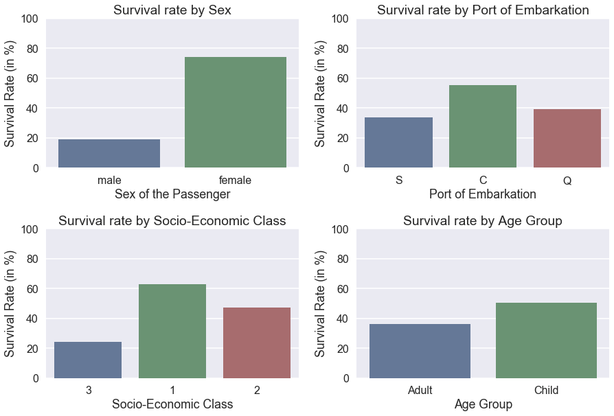

```python
# Plot the rate of survival vs each of the dependent variables (sex,socio-economic class, port of embarkation,age group)
%pylab inline
import matplotlib.pyplot as plt
import seaborn as sns

sns.set(style="darkgrid")
paper_rc = {'lines.linewidth': 1, 'lines.markersize': 1}
sns.set_context("poster", rc = paper_rc)
fig,(ax1) = plt.subplots(nrows=2,ncols=2)

# Use the function above to find survival rate by sex
w = survival_rate('Sex')
sns.factorplot(data=w, saturation=.5, kind="bar", ci=None, size=7, aspect=.9, ax =ax1[0][0])
ax1[0][0].set(xlabel='Sex of the Passenger', ylabel='Survival Rate (in %)', title= 'Survival rate by Sex')
ax1[0][0].set(ylim=(0, 100))
# Use the function above to find survival rate by Port of embarkation
k = survival_rate('Embarked')
sns.factorplot(data=k, saturation=.5, kind="bar", ci=None, size=7, aspect=.9, ax = ax1[0][1])
ax1[0][1].set(xlabel='Port of Embarkation', ylabel='Survival Rate (in %)', title= 'Survival rate by Port of Embarkation')
ax1[0][1].set(ylim=(0, 100))
# Use the function above to find survival rate by socio-economic class
l= survival_rate('Pclass')
sns.factorplot(data=l, saturation=.5, kind="bar", ci=None, size=7, aspect=.9, ax = ax1[1][0])
ax1[1][0].set(xlabel='Socio-Economic Class', ylabel='Survival Rate (in %)', title= 'Survival rate by Socio-Economic Class')
ax1[1][0].set(ylim=(0, 100))
# Use the function above to find survival rate by age group
m = survival_rate('group_age')
sns.factorplot(data=m, saturation=.5, kind="bar", ci=None, size=7, aspect=.9, ax = ax1[1][1])
ax1[1][1].set(xlabel='Age Group', ylabel='Survival Rate (in %)', title= 'Survival rate by Age Group')
ax1[1][1].set(ylim=(0, 100))

fig.tight_layout()

plt.close(2)
plt.close(3)
plt.close(4)
plt.close(5)
```

The visualizations above answer some of my first few questions. It is very clear from the graphs that when analyzed individually, women, passengers from the 1st class, children and passengers who embarked at Port Cherbourg were more likely to survive than their counterparts. Most of my above analysis makes sense and is intuitive as women and children were given more preference as were the rich 1st class passengers. The analysis about passengers who embarked at Cherbourg having a higher survival rate is interesting and not intuitive. I would like to dig deeper here to find out why that is.

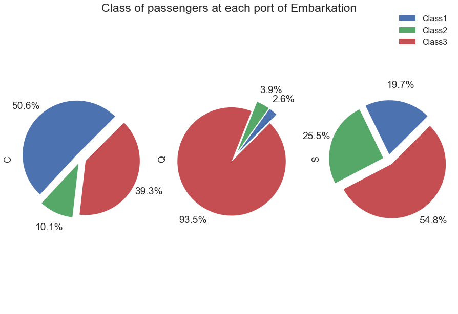

```python
%pylab inline
import matplotlib.pyplot as plt
import seaborn as sns
from matplotlib import font_manager as fm

# Group data by Class and port of embarkation to determine the distibution of passengers across the two
test = (titanic_data_raw.groupby(['Pclass','Embarked'],as_index= False).size())

# Plot the Class of passengers that embarked at each port
sns.set(style="darkgrid")
paper_rc = {'lines.linewidth': 1, 'lines.markersize': 1}
sns.set_context("poster", rc = paper_rc)
explode=(0.15, 0.15,0.15)
class_plot = test.unstack().plot(kind='pie',explode = explode,labels = None,title="Class of passengers at each port of Embarkation", subplots= True,layout=(1,3),autopct='%1.1f%%',startangle=45, radius = 1.5,pctdistance=1.3)
[ax.axis('equal') for ax in plt.gcf().axes]
plt.legend(loc = "best", labels = ['Class1', 'Class2', 'Class3'])
plt.tight_layout()
```

The above analysis shows that suggests that the percentage of 1st class passengers was the highest from this port. This backs up the high survival rate for Cherbourg passengers.

The following analysis to determine the effect of age on survival. For this I am going to carry out a two sample independent t-test and an alpha of 0.05 with the below hypotheses:

*Null Hypothesis:* The mean age of surviving passengers is the same as that of non-surviving passengers.

*Alternate Hypothesis:* The mean age of surviving passenger is different from that of the non-surviving passengers.

```python
# Split survivors from the non-survivors

x = titanic_data_raw[titanic_data_raw['Survived']==0]
y = titanic_data_raw[titanic_data_raw['Survived']==1]

# T test
from scipy.stats import ttest_ind
ttest_ind(x['Age'],y['Age'])
```

```
Ttest_indResult(statistic=2.0266099294090889, pvalue=0.043000401054334787)
```

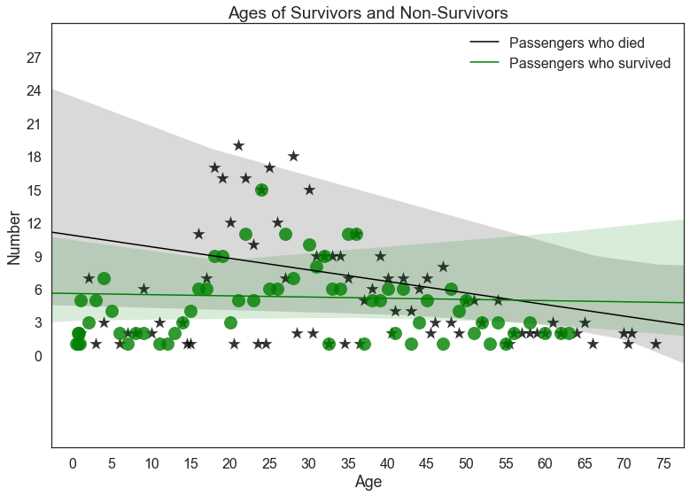

```python
# Group the survivors and non-survivors by age and find the frequency
t1 = pd.DataFrame(x.groupby(['Age'], as_index=False).size().reset_index(name ='Number'))
t2 = pd.DataFrame(y.groupby(['Age'], as_index=False).size().reset_index(name ='Number'))

# Scatter plot of the ages of survivors and non-survivors
sns.set(style="white")
paper_rc = {'lines.linewidth': 1, 'lines.markersize': 15}
sns.set_context("poster", rc = paper_rc)
sns.regplot('Age', 'Number',data=t1,fit_reg=True, marker= '*', color='black', ci = 100,)
sns.regplot('Age', 'Number',data=t2,fit_reg=True, marker= 'o', color='green', ci = 100 )
plt.ylim(top=30)
plt.legend(['Passengers who died', 'Passengers who survived'])
plt.xticks(np.arange(0,80,5))
plt.yticks(np.arange(0,30,3))
plt.title('Ages of Survivors and Non-Survivors')
```

```
   Pclass     Sex  number_survived  total  survival_rate
0       1  female               91     94       0.968085
1       1    male               45    122       0.368852
2       2  female               70     76       0.921053
3       2    male               17    108       0.157407
4       3  female               72    144       0.500000
5       3    male               47    347       0.135447
```

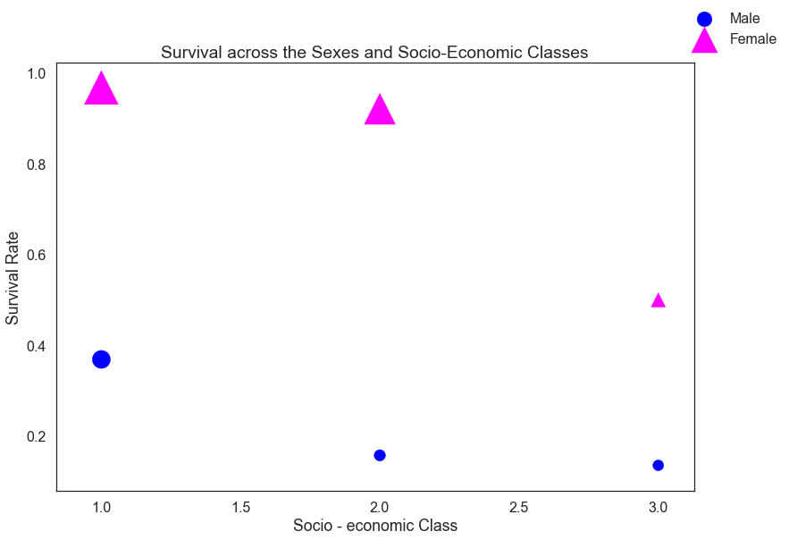

```python
## Calculate the total number of passengers grouped by sex in each socio-economic class
## Calcute the susrvival rate for each such group
%pylab inline
import matplotlib.pyplot as plt
import seaborn as sns
total = pd.DataFrame(titanic_data_raw.groupby(['Pclass','Sex'], as_index= False).size().reset_index(name = 'total'))
Survived = pd.DataFrame(titanic_data_raw.groupby(['Pclass','Sex','Survived'], as_index= False).size().reset_index(name ='number_survived'))
Survived.drop(Survived[Survived.Survived == 0].index, inplace=True)
del Survived['Survived']
Survived= Survived.merge(total, on= ['Pclass', 'Sex'])
Survived['survival_rate'] = Survived.number_survived/Survived.total

print Survived

## Plot the rate of survival of women and men across the  socio-economic classes
sns.set(style="white")
paper_rc = {'lines.linewidth': 1, 'lines.markersize': 10}
sns.set_context("poster", rc = paper_rc)

#Define Values for the x and y axes
xm = Survived[Survived['Sex']=='male'].loc[:, 'Pclass']
xf = Survived[Survived['Sex']=='female'].loc[:, 'Pclass']
y = Survived.loc[:,'survival_rate']
m = Survived[Survived['Sex']=='male'].loc[:,'survival_rate']
f = Survived[Survived['Sex']=='female'].loc[:,'survival_rate']

#Define size of the bubble
sm = [80*80**n for n in m]
sf = [40*40**n for n in f]

# Plot a Scatter plot
plt.figure(1)
male_plot = plt.scatter(xm,m,s=sm,c='b', marker='o')
female_plot = plt.scatter(xf,f,s=sf,color='magenta', marker='^')
plt.legend([male_plot, female_plot], ['Male', 'Female'], bbox_to_anchor=(1.15, 1.15))
plt.xlabel('Socio - economic Class')
plt.ylabel('Survival Rate')
plt.title('Survival across the Sexes and Socio-Economic Classes')
```

It is apparent from the above table and visualization that women from the 1st class had a very good chance of survival at ~97% as compared to women from the 3rd class who had a survival rate of only ~50%. Women also had a higher survival rate than the men of a similar socio-economic class, with men haveing only a ~37% survival rate in the 1st class and a ~14% survival rate in the 3rd class. This answers my question about women from upper classes.

```python
# Function to check for the presence of family
def with_without_family(df):
    if ((df['Parch'] == 0)& (df['SibSp']== 0)):
        return 'No family'
    else:
        return 'With family'

titanic_data_raw['Family'] = titanic_data_raw.apply(with_without_family,axis =1)
```

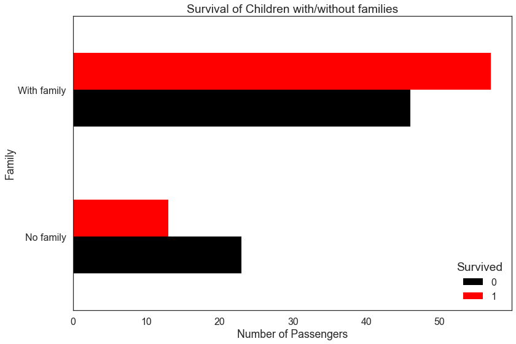

```python
# Function to determine the influence of the presence/absence of a family on survival of children

survival_children= (titanic_data_raw[titanic_data_raw['group_age']=='Child'].groupby(['Family','Survived'],as_index= False).size())

# Plot the survival of children vs presence of family
sns.set(style="white")
paper_rc = {'lines.linewidth': 1, 'lines.markersize': 100}
sns.set_context("poster", rc = paper_rc)

survival_children_plot= survival_children.unstack().plot(kind='barh',title="Survival of Children with/without families",color = ['black','red'])
survival_children_plot.set_xlabel("Number of Passengers")
```

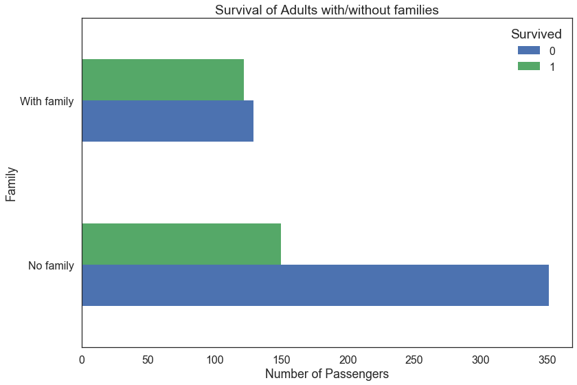

```python
# Function to determine the influence of the presence/absence of a family on survival of adults
survival_adults= (titanic_data_raw[titanic_data_raw['group_age']=='Adult'].groupby(['Family','Survived'],as_index= False).size())



# Plot the survival of adults vs presence of family

sns.set(style="white")
paper_rc = {'lines.linewidth': 1, 'lines.markersize': 100}
sns.set_context("poster", rc = paper_rc)

survival_adults_plot= survival_adults.unstack().plot(kind='barh',title="Survival of Adults with/without families")
survival_adults_plot.set_xlabel("Number of Passengers")
```

It makes sense that children with families had a better chance of surviving than those without. However, it seems counter-intuitive that a large number of adults without families died. I am going to look into this a little further to see other factors involved.

```python
# Group by Pclass and Sex and calculate the survival rate
p = pd.DataFrame(titanic_data_raw[titanic_data_raw['group_age']=='Adult'].groupby(['Family','Survived','Pclass','Sex'],as_index= False).size().reset_index(name = 'Number of Passengers'))
died_without_family = p[(p['Survived']== 0)& (p['Family'] == 'No family')]
total = p[(p['Survived']== 0)& (p['Family'] == 'No family')]['Number of Passengers'].sum()
died_without_family['Percentage of Passengers']=(died_without_family['Number of Passengers']/total) *100
died_without_family.head(10)

died_without_family.style.bar(subset=['Number of Passengers', 'Percentage of Passengers'], color='lightgreen')
```

|  | Family | Survived | Pclass | Sex | Number of Passengers | Percentage of Passengers |
| --- | --- | --- | --- | --- | --- | --- |
| 0 | No family | 0 | 1 | female | 1 | 0.2849 |
| 1 | No family | 0 | 1 | male | 50 | 14.245 |
| 2 | No family | 0 | 2 | female | 3 | 0.854701 |
| 3 | No family | 0 | 2 | male | 59 | 16.8091 |
| 4 | No family | 0 | 3 | female | 19 | 5.41311 |
| 5 | No family | 0 | 3 | male | 219 | 62.3932 |

A quick look at the above table helps understand the abysmal survival rate of adults without families. 62% of the passengers without families who died were males from the third class.

# Conclusion

# Assumptions and Limitations

# References

https://www.datacamp.com/community/tutorials/matplotlib-tutorial-python

https://measuringu.com/handle-missing-data/

https://www.kaggle.com/c/titanic/data

https://docs.scipy.org/doc/scipy-0.15.1/reference/generated/scipy.stats.ttest_ind.html

https://seaborn.pydata.org/

https://matplotlib.org/

http://pandas.pydata.org/pandas-docs/stable/style.html